# Внешний курс 3 этап

Архитектура компьютеров и операционные системы

Венис Дмитрий

1032253513@rudn.ru

Российский университет дружбы народов

2026-05-03

# Информация

## Докладчик

- Венис Дмитрий
- студент НКАбд-01-25
- Российский университет дружбы народов им. П. Лумумбы
- 1032253513@rudn.ru
- https://github.com/VenisDmitry

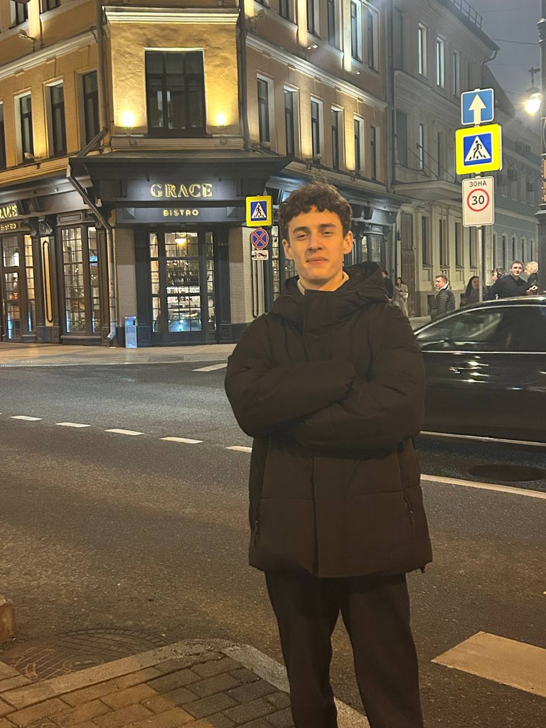

# Цель работы

Целью работы является прохождение третьего этапа внешнего курса «Введение в Linux» и закрепление практических навыков работы с редактором `vim`, написанием `bash`-скриптов, использованием условий, циклов и функций, применением команд `find`, `grep`, `sed`, `gnuplot`, а также управлением правами доступа и файловыми утилитами Linux.

# Задание

Необходимо пройти задания третьего этапа внешнего курса и подготовить отчёт по всем выполненным активностям. Для каждого тестового вопроса и практического задания требуется привести:

- скриншот с формулировкой задания;
- скриншот, подтверждающий успешное прохождение;
- краткое пояснение по выбору ответа или выполнению задания.

# Выполнение работы

## Текстовый редактор vim

Указал, что для выхода из редактора `vim` сразу после открытия файла нужно нажать `:`, затем `q`, затем `Enter` (Рисунок 1).

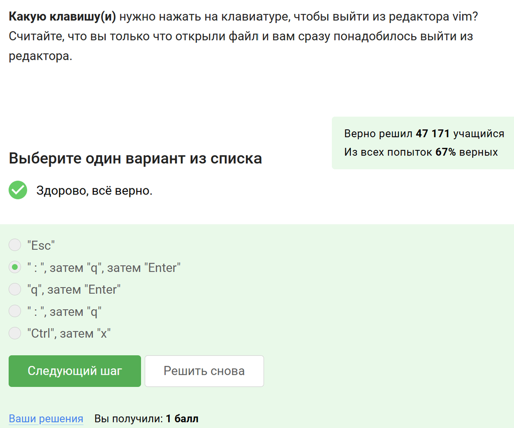

Рисунок 1: Выбор комбинации клавиш для выхода из vim

В задании требовалось определить правильную последовательность действий для выхода из `vim`, если файл только что открыт и изменений в нём нет. Правильным вариантом является команда `:q`, которая завершает работу редактора.

Изучил различие между перемещением по `word` и `WORD` в `vim` и отметил верные утверждения для заданной строки (Рисунок 2).

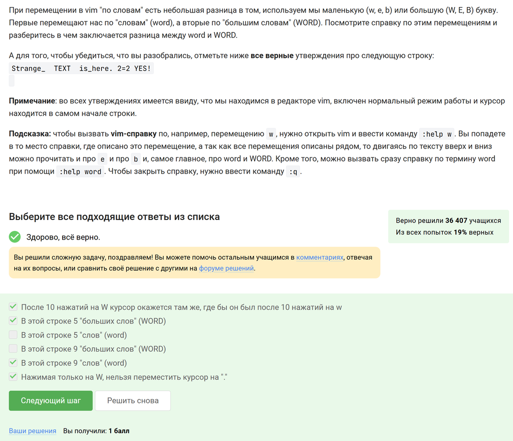

Рисунок 2: Задание на различие word и WORD в vim

В этом задании нужно было разобраться, что команды с маленькими буквами работают со словами в обычном понимании, а команды с заглавными — с последовательностями символов до разделителя-пробела. Поэтому были выбраны только те утверждения, которые соответствуют этому различию.

Определил корректные наборы нажатий клавиш, позволяющие преобразовать строку `one two three four five` в строку `three four four four five` (Рисунок 3).

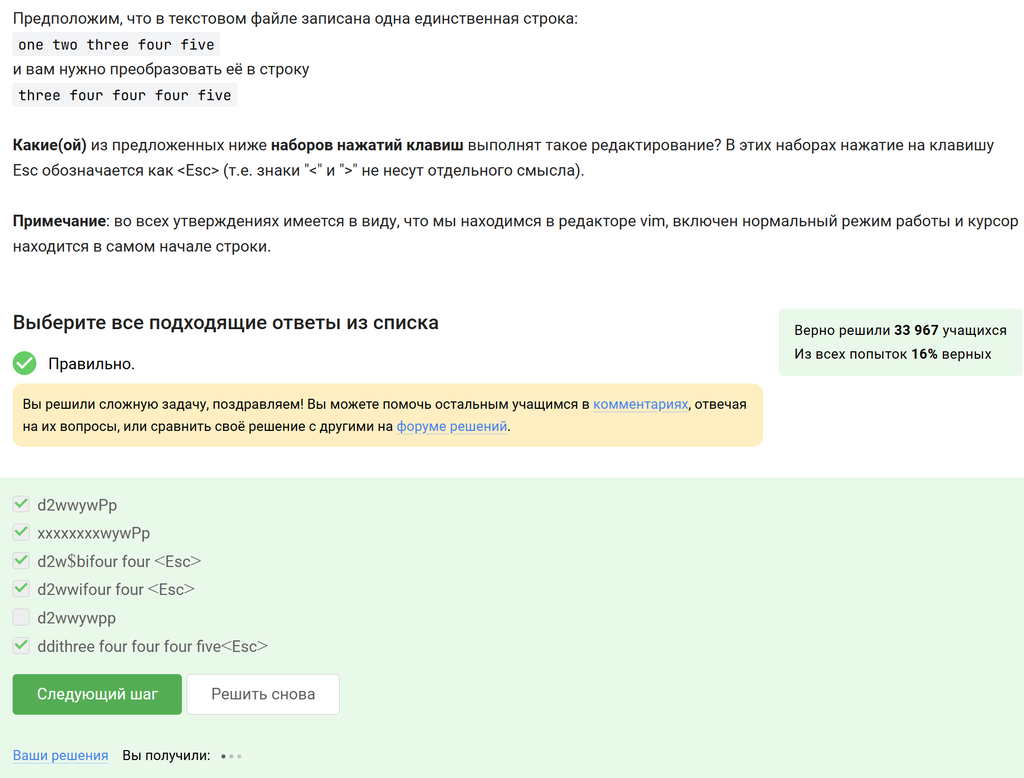

Рисунок 3: Редактирование строки в vim с помощью команд normal mode

Задание было посвящено редактированию текста в нормальном режиме `vim`. Были отмечены только те комбинации, которые действительно приводят к требуемому результату, используя удаление, перемещение и вставку текста.

Ввёл команду `:%s/Windows/Linux`, чтобы заменить в файле все строки, содержащие слово `Windows`, на такие же строки со словом `Linux`, причём в каждой строке заменялось только первое вхождение (Рисунок 4).

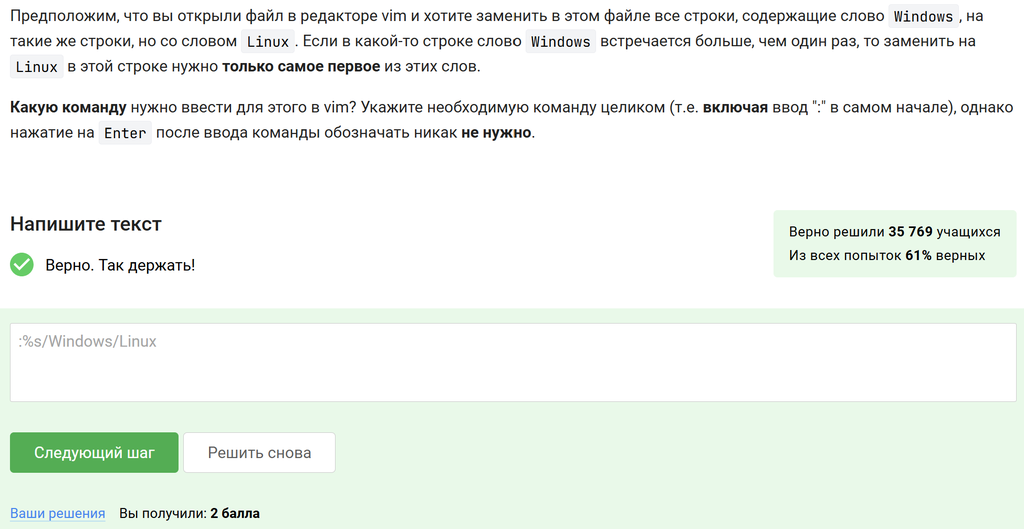

Рисунок 4: Команда замены текста в vim

Здесь требовалось использовать команду подстановки в `vim`. Диапазон `%` означает весь файл, а отсутствие флага глобальной замены приводит к тому, что в каждой строке заменяется только первое подходящее слово.

Самостоятельно разобрался с визуальным режимом `vim` и отметил правильные утверждения о его работе (Рисунок 5).

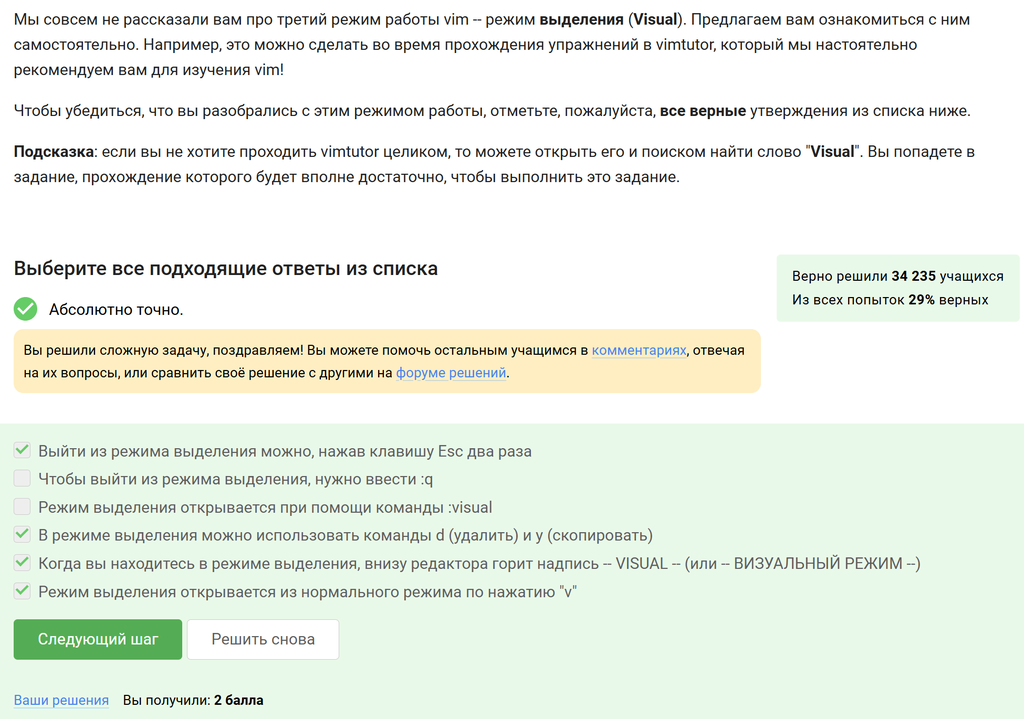

Рисунок 5: Задание по Visual mode в vim

В этом задании были подтверждены основные свойства режима выделения: вход по клавише `v`, возможность использовать команды удаления и копирования, а также отображение строки состояния `-- VISUAL --`. Также было отмечено, что выйти из режима выделения можно клавишей `Esc`.

## Скрипты на bash: основы

Указал, что при перемещении по истории команд стрелками вверх и вниз после запуска нескольких вложенных оболочек будут показываться только команды из текущей оболочки, то есть из набора `C` (Рисунок 6).

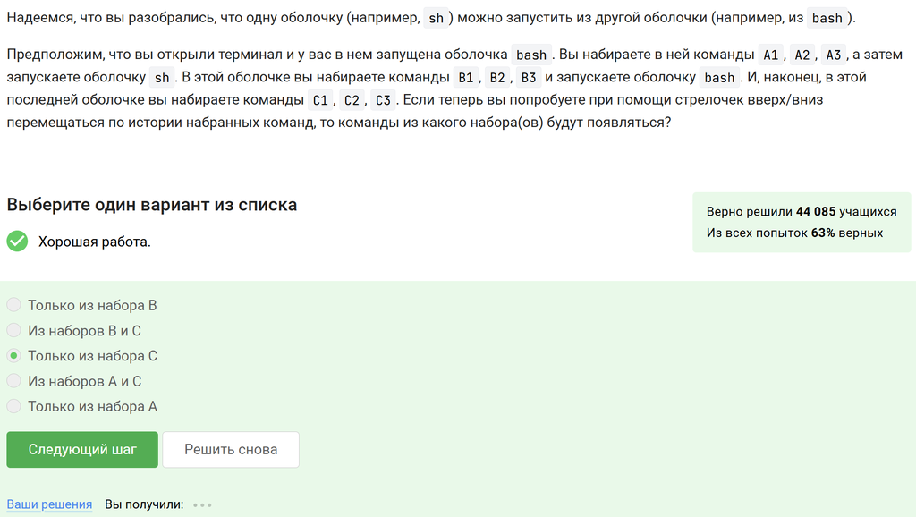

Рисунок 6: История команд во вложенных оболочках bash и sh

История команд хранится отдельно для каждой активной оболочки. Поэтому при работе во внутренней оболочке доступны только те команды, которые были введены именно в ней.

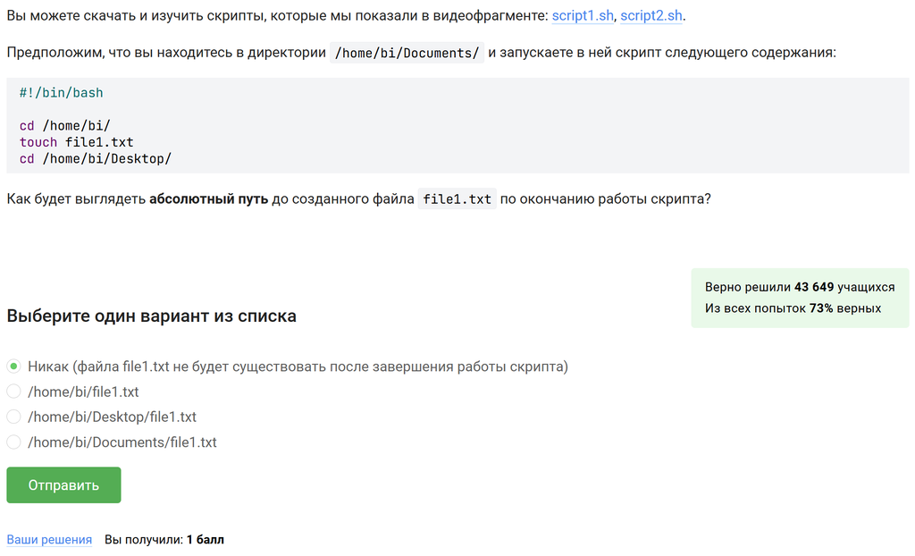

Рисунок 7: Задание о пути к файлу после выполнения bash-скрипта

Отметил допустимые имена переменных в `bash`: `_variable`, `VARiable`, `variable123` (Рисунок 8).

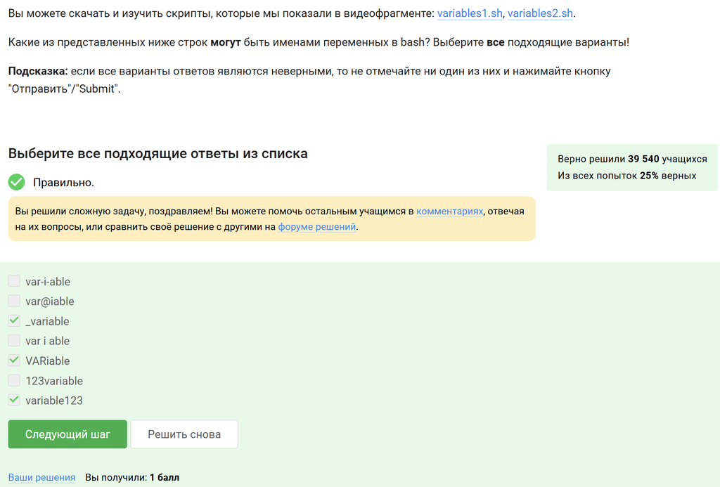

Рисунок 8: Допустимые имена переменных в bash

В `bash` имя переменной может содержать буквы, цифры и символ подчёркивания, но не должно начинаться с цифры и не должно содержать пробелы или специальные символы вроде `-` и `@`.

Написал скрипт, принимающий два аргумента командной строки и выводящий их в формате `Arguments are: $1=... $2=...` (Рисунок 9).

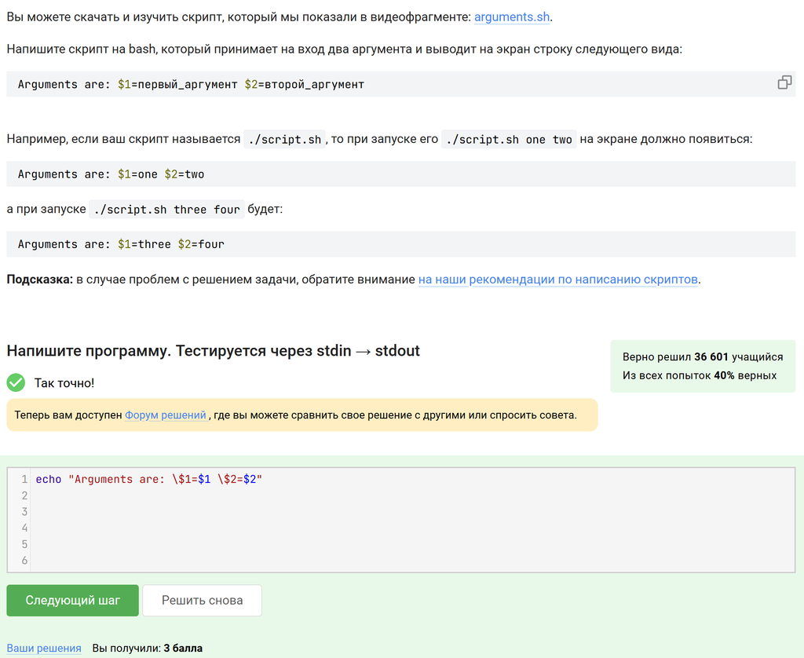

Рисунок 9: Скрипт для вывода аргументов командной строки

В решении использовались позиционные параметры `$1` и `$2`. Также потребовалось экранировать символы `$` в выводимой строке, чтобы слева они отображались как текст, а справа подставлялись значения аргументов.

## Скрипты на bash: ветвления и циклы

В задании по условным выражениям отметил только те варианты, при которых команда `echo "True"` будет выполняться всегда, независимо от параметров запуска скрипта и значений переменных (Рисунок 10).

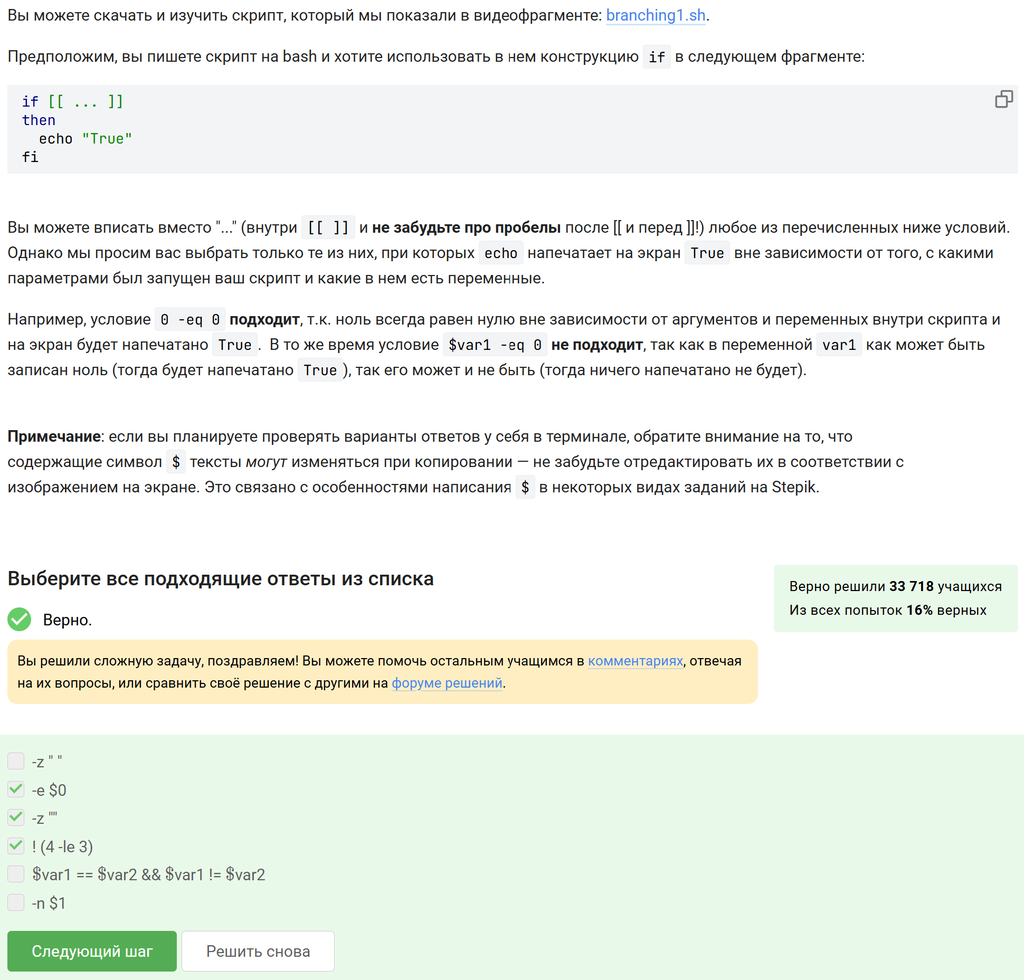

Рисунок 10: Условия в конструкции if в bash

Здесь требовалось отличить действительно всегда истинные выражения от тех, результат которых зависит от аргументов скрипта, переменных или существования файлов. Были выбраны только универсально истинные условия.

Определил, что при запуске фрагмента скрипта с `var=3`, а затем с `var=5`, на экран сначала выводится `four`, а потом снова `four` (Рисунок 11).

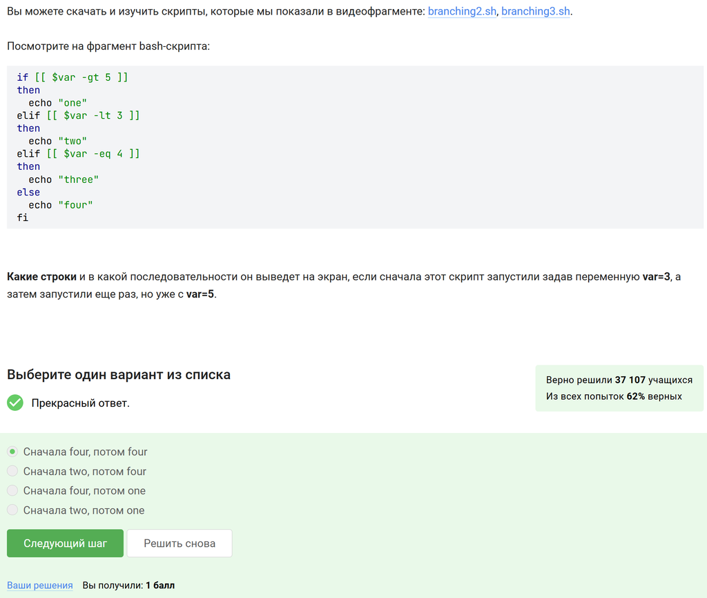

Рисунок 11: Определение результата цепочки if elif else

Проверка условий выполняется сверху вниз. Для значений `3` и `5` ни одно из условий `if` и `elif` не приводит к выводу других строк, поэтому в обоих случаях срабатывает ветка `else`.

Написал скрипт, который по количеству студентов выводит одну из строк: `No students`, `1 student`, `2 students`, `3 students`, `4 students` или `A lot of students` (Рисунок 12).

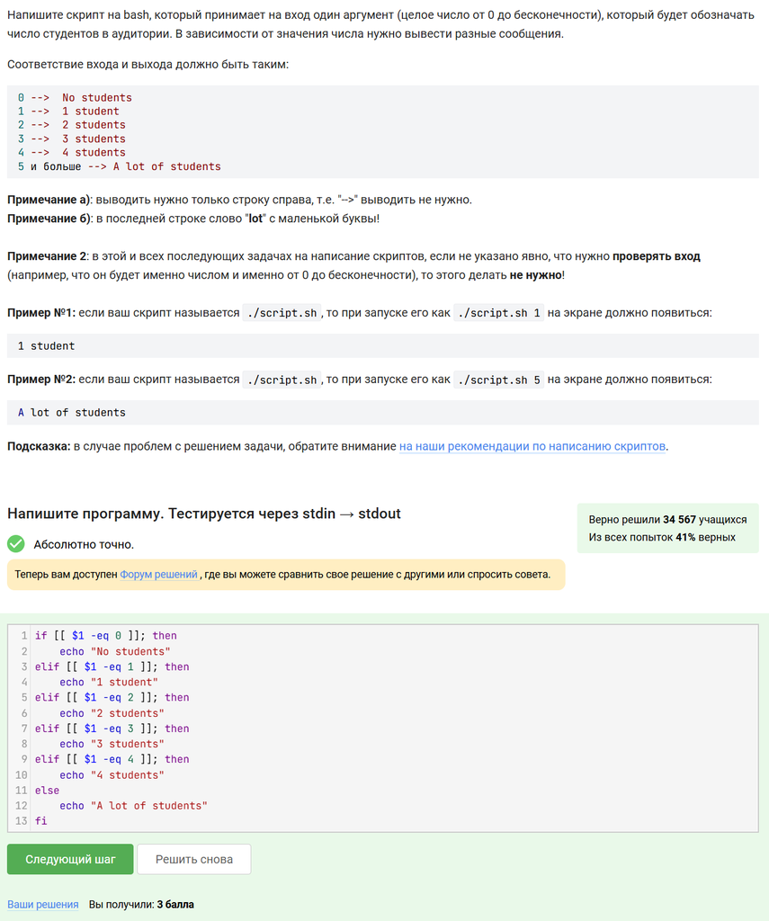

Рисунок 12: Скрипт с ветвлением по количеству студентов

В этом задании использовалась последовательность проверок через `if`, `elif` и `else`, позволяющая обработать отдельно случаи от `0` до `4`, а все большие значения отнести к общей категории.

Указал, что в данном фрагменте цикла слово `start` выводится 5 раз, а слово `finish` — 4 раза (Рисунок 13).

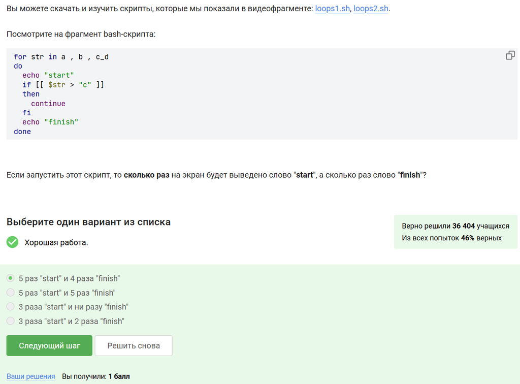

Рисунок 13: Работа цикла for и continue в bash

Команда `echo "start"` выполняется на каждой итерации цикла. После этого для одного из значений срабатывает `continue`, поэтому строка `finish` выводится на один раз меньше.

Написал интерактивный скрипт, который запрашивает имя и возраст пользователя, определяет возрастную группу (`child`, `youth`, `adult`) и завершает работу по пустому имени или возрасту `0` (Рисунок 14).

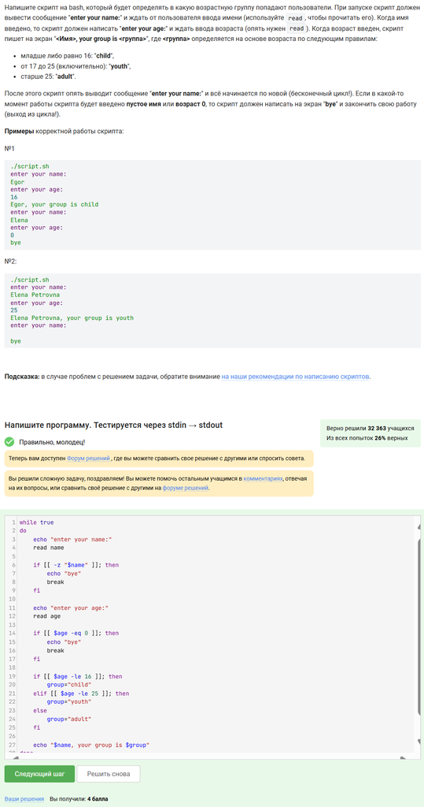

Рисунок 14: Интерактивный bash-скрипт с бесконечным циклом

Для решения использовались команды `read`, условные операторы и бесконечный цикл. Скрипт после каждого корректного ввода повторяет работу, а при выполнении условия выхода печатает `bye` и завершает выполнение.

## Скрипты на bash: разное

Отметил все инструкции, которые увеличивают значение переменной `a` на значение переменной `b` (Рисунок 15).

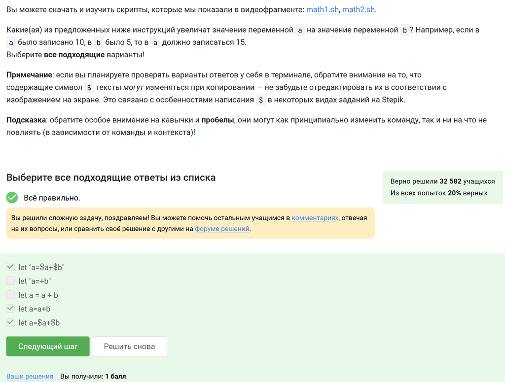

Рисунок 15: Арифметические операции с переменными в bash

Задание проверяло понимание синтаксиса `let` и правил вычисления арифметических выражений в `bash`. Были выбраны только те формы записи, которые действительно изменяют переменную `a` на сумму прежнего значения `a` и значения `b`.

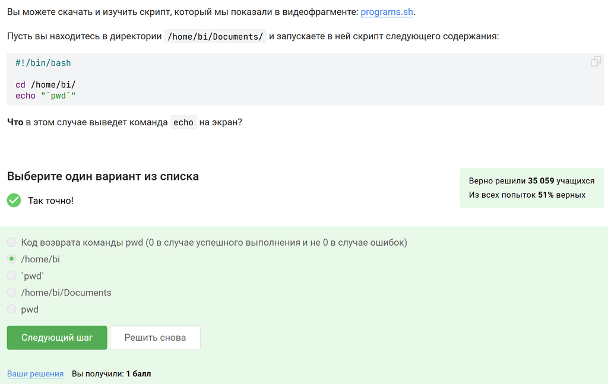

Рисунок 16: Различие между pwd и echo “pwd”

Указал верные способы проверить код возврата внешней программы, если она пишет что-то в `stdout` (Рисунок 17).

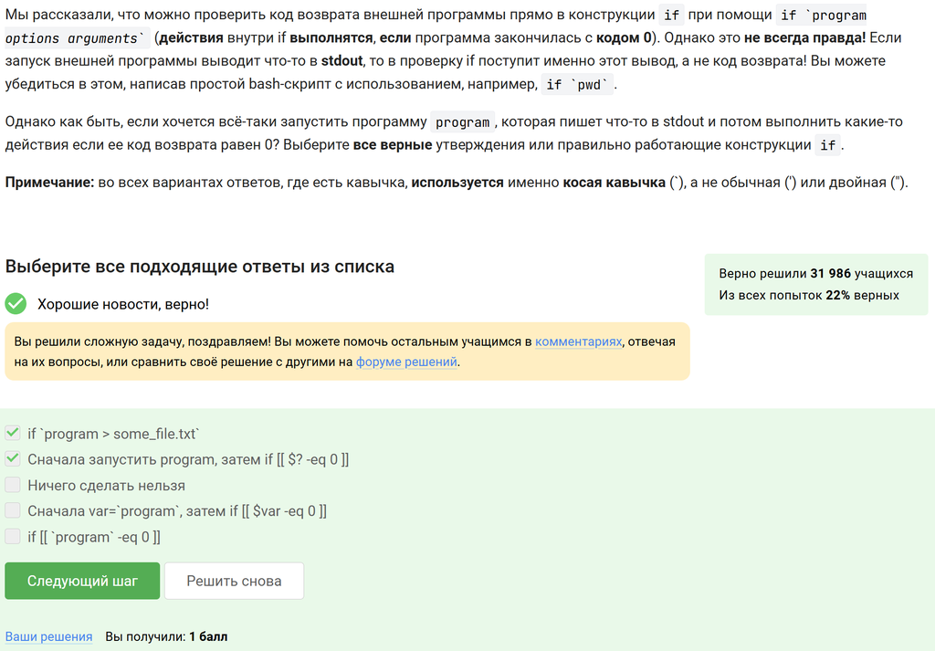

Рисунок 17: Проверка кода возврата внешней программы в bash

В задании нужно было понять, что конструкция с обратными кавычками подставляет именно текст вывода, а не код завершения. Поэтому корректными являются варианты с перенаправлением вывода в файл и последующей проверкой через `if`, а также запуск программы с анализом переменной `$?`.

Определил результат десяти вызовов функции `counter`: строка, выводимая командой `echo`, имеет вид `counters are and 110` (Рисунок 18).

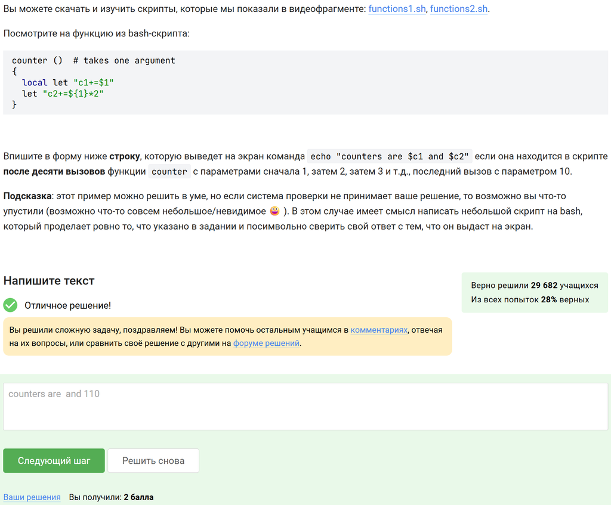

Рисунок 18: Задание на локальные и глобальные переменные в функции bash

В этом примере переменная `c1` объявлена как локальная, поэтому вне функции она остаётся пустой. Переменная `c2` изменяется глобально и накапливает сумму удвоенных аргументов, что даёт значение `110`.

Написал рекурсивный скрипт для вычисления наибольшего общего делителя двух чисел по алгоритму Евклида (Рисунок 19).

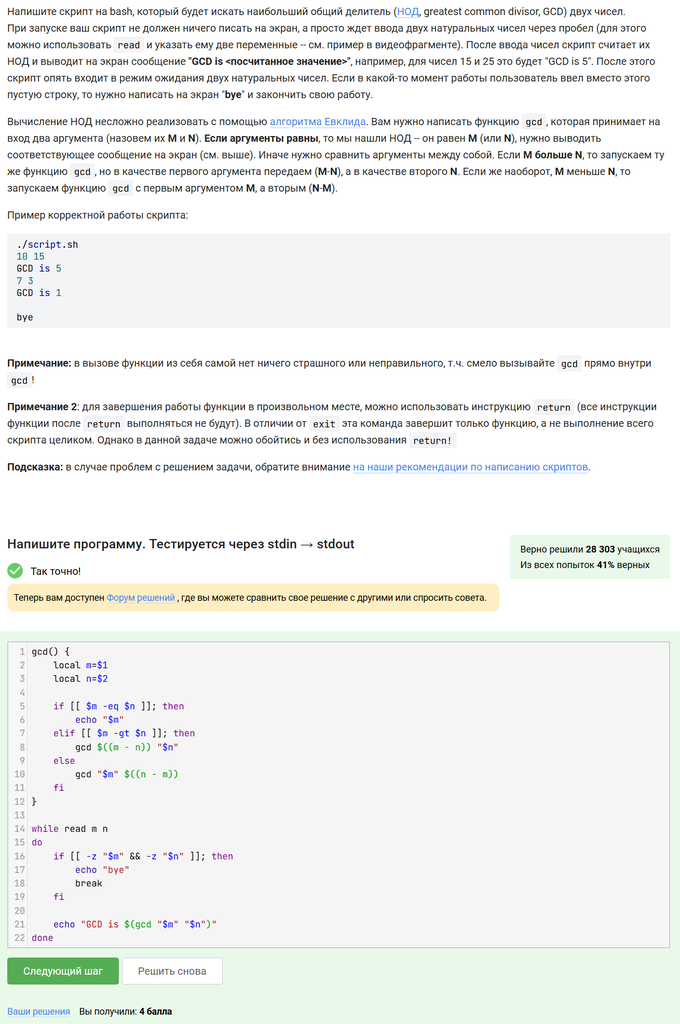

Рисунок 19: Рекурсивный bash-скрипт для вычисления НОД

Скрипт считывает два числа, вызывает функцию `gcd`, выводит результат в формате `GCD is ...`, затем снова ожидает ввод. При пустой строке работа корректно завершается сообщением `bye`.

Написал калькулятор на `bash`, который поддерживает операции `+`, `-`, `*`, `/`, `%`, `**`, завершает работу по команде `exit` и выводит `error` при некорректной команде (Рисунок 20).

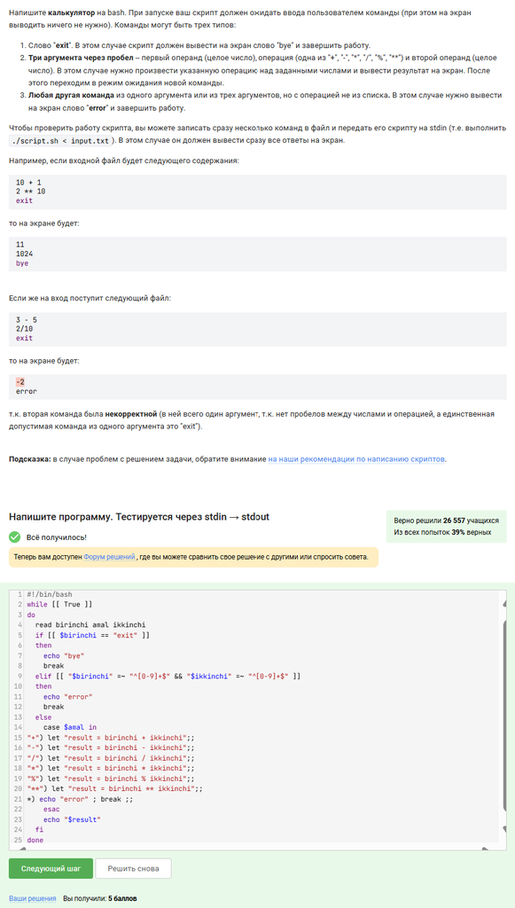

Рисунок 20: Калькулятор на bash

В решении использовалось чтение строк из стандартного ввода, разбор аргументов и проверка допустимости операции. Скрипт выполняет вычисление только для корректного формата ввода.

## Продвинутый поиск и редактирование

Указал, что команда `find /home/bi -iname "star*"` найдёт, а команда `find /home/bi -name "star*"` не найдёт файлы `STARS.txt` и `Star_Wars.avi` (Рисунок 21).

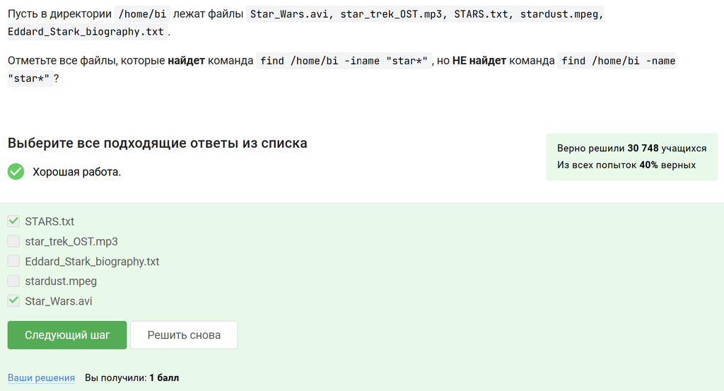

Рисунок 21: Сравнение find -iname и find -name

Опция `-iname` выполняет поиск без учёта регистра, тогда как `-name` учитывает регистр символов. Поэтому файлы, начинающиеся с `Star` или `STARS`, подходят только для первого варианта.

Отметил верные утверждения о различии опций `find -path` и `find -name` (Рисунок 22).

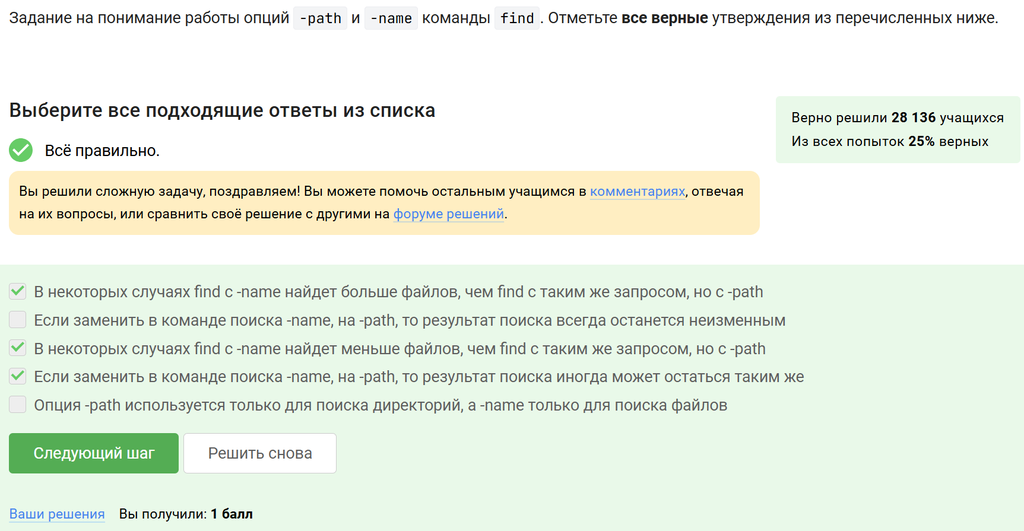

Рисунок 22: Понимание различий между -path и -name в find

Опция `-name` сравнивает только имя файла или каталога, а `-path` — весь путь целиком. Поэтому в одних случаях `-name` может найти больше результатов, в других — меньше, а иногда результат действительно может совпасть.

Определил, что команда `find /home/bi -mindepth 2 -maxdepth 3 -name "file*"` найдёт все файлы, кроме `file3` (Рисунок 23).

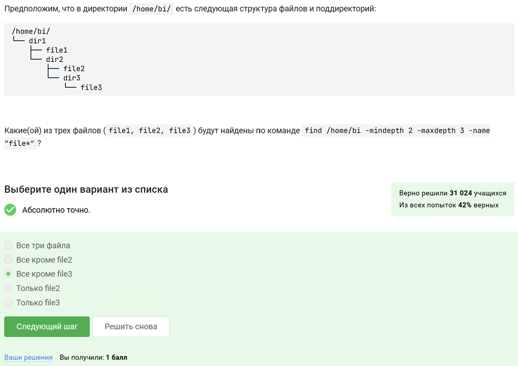

Рисунок 23: Использование -mindepth и -maxdepth в find

Ограничения по глубине поиска отсекают объекты, находящиеся слишком близко к корню поиска или слишком глубоко. Поэтому файл `file3` не попадает в нужный диапазон глубины.

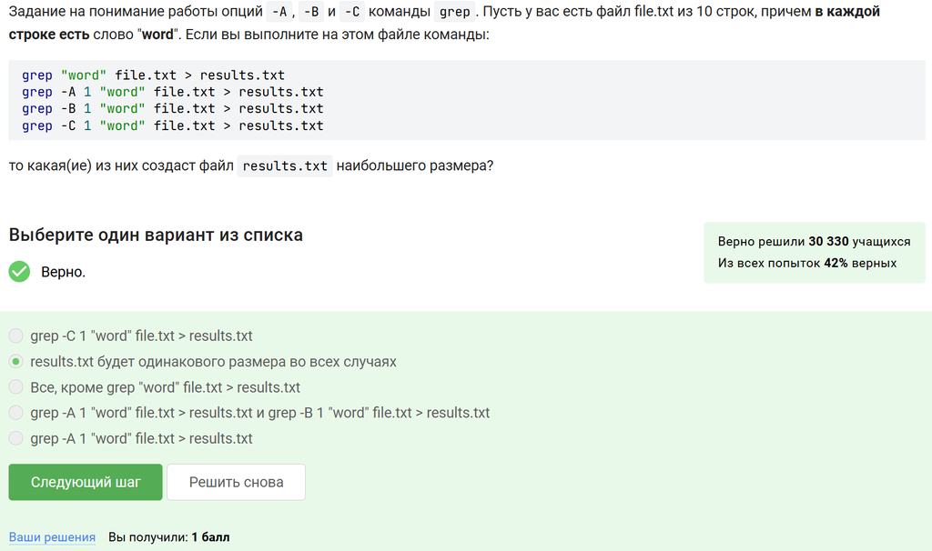

Рисунок 24: Опции контекста в grep

Отметил строки, которые выводит команда `grep -E "[xkLXKL]?[uU]buntu$" text.txt` (Рисунок 25).

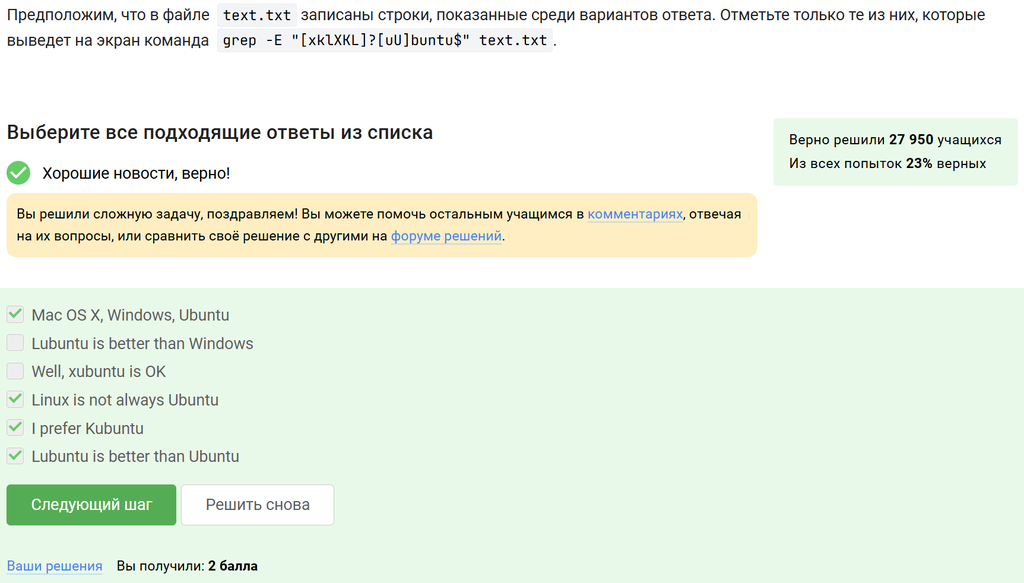

Рисунок 25: Регулярные выражения в grep -E

Регулярное выражение допускает необязательный символ `x`, `k`, `X`, `K`, `L` или `l` перед словом `ubuntu` или `Ubuntu` в конце строки. Поэтому были выбраны только те строки, которые удовлетворяют именно этой форме записи.

Составил инструкцию `sed`, которая заменяет все «аббревиатуры» из заглавных латинских букв на слово `abbreviation` и записывает результат в файл `edited.txt` (Рисунок 26).

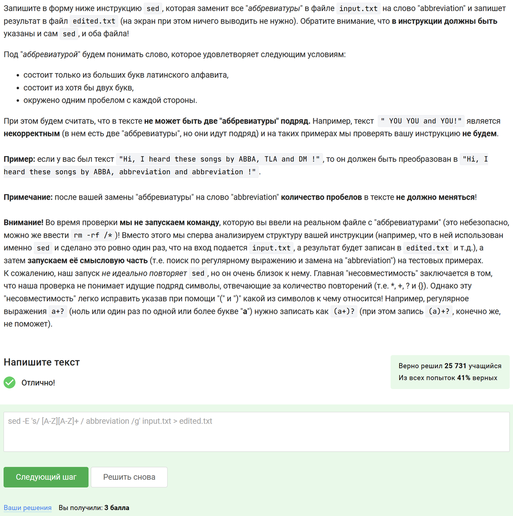

Рисунок 26: Практическое задание по замене текста через sed

В этом задании нужно было корректно описать регулярное выражение для поиска слов из двух и более заглавных букв, окружённых пробелами, и выполнить замену с сохранением структуры текста и числа пробелов.

## Строим графики в gnuplot

Указал, что при запуске `gnuplot` для сохранения построенных графиков после выхода из программы нужно использовать опцию `-p` (`--persist`) (Рисунок 27).

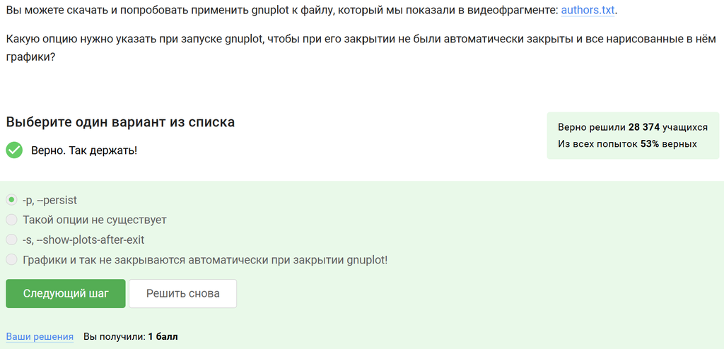

Рисунок 27: Опция persist при запуске gnuplot

Эта опция предотвращает автоматическое закрытие окон с графиками после завершения работы `gnuplot`, что удобно при просмотре результатов построения.

Определил, что при командах `set key autotitle columnhead` и `plot 'data.csv' using 1:2` названием ряда данных станет первое значение из второго столбца, а на графике будет нарисовано 9 точек (Рисунок 28).

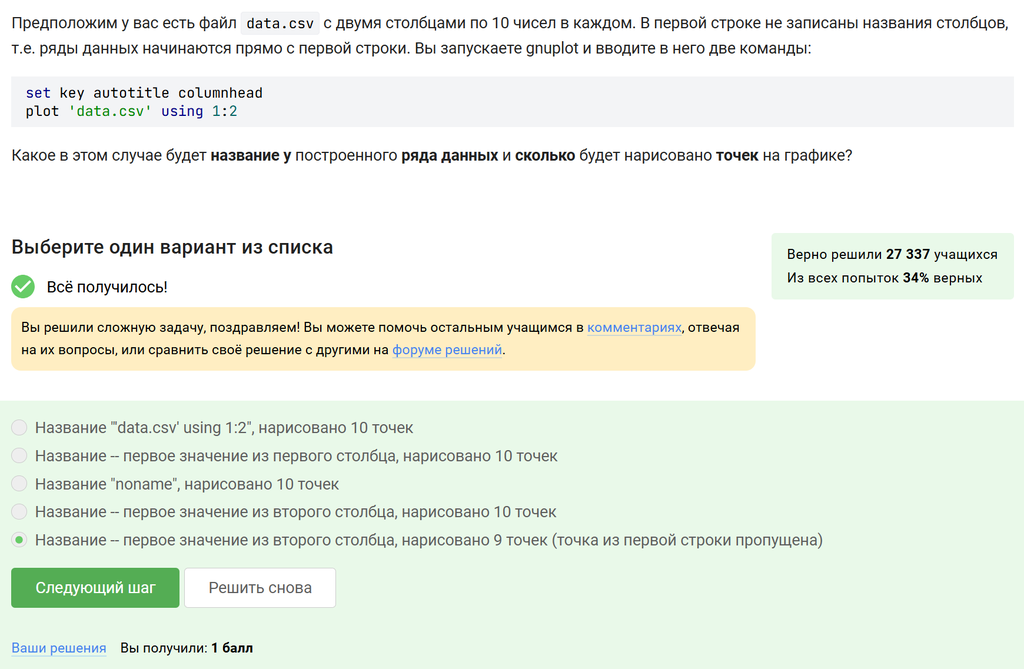

Рисунок 28: Название ряда и число точек в gnuplot

Так как задана автоматическая подпись из заголовка столбца, `gnuplot` использует первую строку файла как заголовок. Поэтому она не участвует в построении как точка, и остаётся 9 точек данных.

Изменил файл `move.rot` так, чтобы график зеркально отразился относительно горизонтальной плоскости, начал вращаться в обратную сторону и делал это в два раза быстрее (Рисунок 29, Рисунок 30).

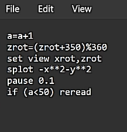

Рисунок 29: Изменённое содержимое файла move.rot

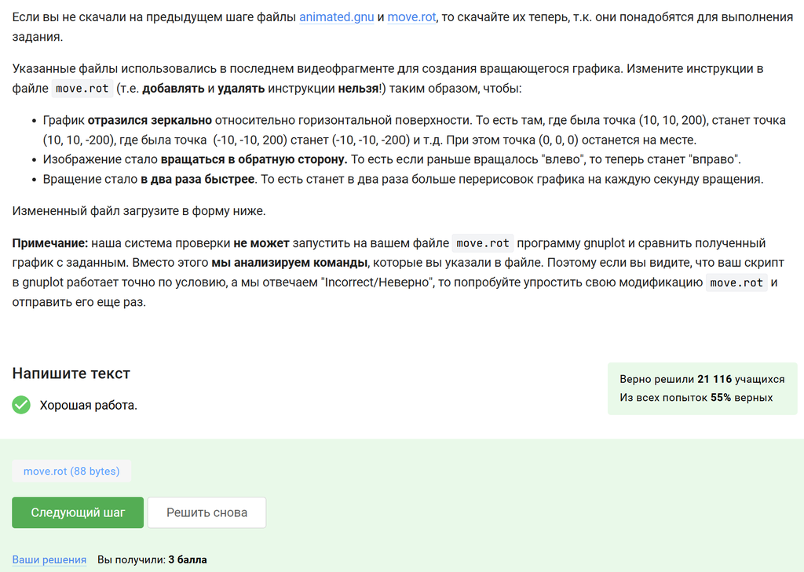

Рисунок 30: Проверка задания по изменению move.rot

Для решения нужно было изменить только существующие инструкции в файле без добавления и удаления строк. Отражение графика было достигнуто сменой знака у выражения для поверхности, обратное вращение — изменением направления изменения угла, а увеличение скорости — уменьшением времени паузы между перерисовками.